# Bi-directional converter

A single-phase bi-directional voltage source conveter is connected to an AC voltage source through an impedance $Z = R + j\,\omega\,L$ with $R=10\,\Omega$ and $L=0.1\,$H. The waveform of the voltage source $v_s$ is a square wave from $300\,$V to $-300\,$V. The phase and frequency of $v_s$ is the same as that of the output voltage $v_{BD}$ of the converter. The DC link voltage $V_{DC}=400\,$V. If the inverter frequency is $100\,$Hz, what is the average value of $i_{dc}$?

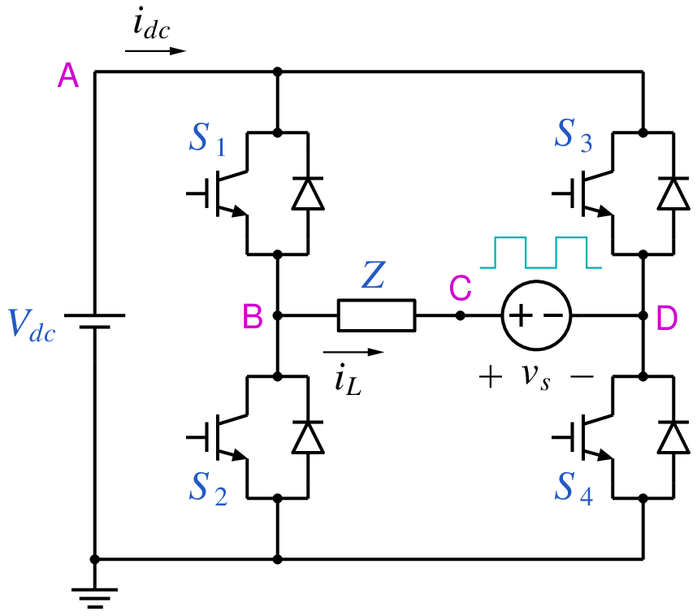

```python
from IPython.display import Image
Image(filename =r'VSC_bi_7_fig_1.png', width=320)
```

```python
# run this cell to view the circuit file.
%pycat VSC_bi_7_orig.in
```

We now replace the strings such as \$Vdc, \$L, with the values of our choice by running the python script given below. It takes an existing circuit file `VSC_bi_7_orig.in` and produces a new circuit file `VSC_bi_7.in`, after replacing \$Vdc, \$L, etc. with values of our choice.

```python
import gseim_calc as calc
s_Vdc = '400'
s_R = '10'
s_L = '0.1'

s_f_hz = "100"
f_hz = float(s_f_hz)

T = 1/f_hz
s_Tby2 = ("%11.4E"%(T/2)).strip()

VS1_peak = 300.0

s_L1 = ("%11.4E"%VS1_peak).strip()
s_L2 = ("%11.4E"%(-VS1_peak)).strip()

l = [
  ('$Vdc', s_Vdc),
  ('$R', s_R),
  ('$L', s_L),
  ('$f_hz', s_f_hz),
  ('$Tby2', s_Tby2),
  ('$VS1_L1', s_L1),
  ('$VS1_L2', s_L2)
]
calc.replace_strings_1("VSC_bi_7_orig.in", "VSC_bi_7.in", l)
print('VSC_bi_7.in is ready for execution')
```

```
VSC_bi_7.in is ready for execution
```

**Execute the following cell to run GSEIM on VSC_bi_7.in.**

```python
import os
import dos_unix
# uncomment for windows:
#dos_unix.d2u("VSC_bi_7.in")
os.system('run_gseim VSC_bi_7.in')
```

```
Circuit: filename = VSC_bi_7.in
main: calling solve_sss
solve_sss starting: sss_n_st: 1
solve_sss_ex: sss_iter_newton=0, rhs_sss_norm=2.0933e+00, sss_period_1_compute=2.0000e-02
solve_sss_ex: sss_iter_newton=1, rhs_sss_norm=4.4409e-16, sss_period_1_compute=2.0000e-02
solve_sss_ex: calling sss_solve_trns_ex for one more trns step
Transient simulation starts...
i=0
GSEIM: Program completed.
```

```
0
```

The circuit file (`VSC_bi_7.in`) is created in the same directory as that used for launching Jupyter notebook. The last step (i.e., running `GSEIM` on `VSC_bi_7.in`) creates a data file called `VSC_bi_7.dat`in the same directory. We can now use the python code below to compute/plot the various quantities of interest.

```
filename: VSC_bi_7.dat
average DC source current:  2.0827E-01
rms DC source current:  1.4224E+00
rms load current:  1.4224E+00
peak load current:  2.4520E+00
power absorbed by load:  2.0231E+01
power delivered by Vdc:  8.3306E+01
power delivered by VS1: -6.2595E+01
peak Idc: 2.452191
peak IL: 2.452031
```

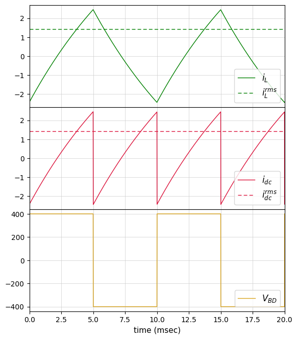

```python
import numpy as np
import matplotlib.pyplot as plt
import gseim_calc as calc
from setsize import set_size

slv = calc.slv("VSC_bi_7.in")

i_slv = 0
i_out = 0
filename = slv.l_filename_all[i_slv][i_out]
print('filename:', filename)
u = np.loadtxt(filename)
t1 = u[:, 0]
t = 1e3*t1 # convert time to msec

v_BD = slv.get_array_double(i_slv,i_out,"v_BD",u)
IR   = slv.get_array_double(i_slv,i_out,"IR"  ,u)
Idc  = slv.get_array_double(i_slv,i_out,"Idc" ,u)
P_R  = slv.get_array_double(i_slv,i_out,"P_R" ,u)
P_dc = slv.get_array_double(i_slv,i_out,"P_dc",u)
P_S1 = slv.get_array_double(i_slv,i_out,"P_S1",u)
g1   = slv.get_array_double(i_slv,i_out,"g1"  ,u)
g2   = slv.get_array_double(i_slv,i_out,"g2"  ,u)

# since we have stored two cycles, we need to divide the last time point
# by 2 to get the period:

T = t[-1]/2

l_IR   = calc.avg_rms_3a(t, IR  , 0.0, 2.0*T, 1.0e-4*T)
l_P_R  = calc.avg_rms_3a(t, P_R , 0.0, 2.0*T, 1.0e-4*T)
l_P_dc = calc.avg_rms_3a(t, P_dc, 0.0, 2.0*T, 1.0e-4*T)
l_P_S1 = calc.avg_rms_3a(t, P_S1, 0.0, 2.0*T, 1.0e-4*T)
l_Idc  = calc.avg_rms_3a(t, Idc , 0.0, 2.0*T, 1.0e-4*T)

l_IR_1  = calc.min_max_1(t, IR , 0.0, 2.0*T)
l_Idc_1 = calc.min_max_1(t, Idc, 0.0, 2.0*T)

print('average DC source current:', "%11.4E"%l_Idc[0])
print('rms DC source current:', "%11.4E"%l_Idc[1])
print('rms load current:', "%11.4E"%l_IR[1])
print('peak load current:', "%11.4E"%l_IR_1[1])
print('power absorbed by load:', "%11.4E"%l_P_R[0])
print('power delivered by Vdc:', "%11.4E"%l_P_dc[0])
print('power delivered by VS1:', "%11.4E"%l_P_S1[0])
print('peak Idc:', l_Idc_1[1])
print('peak IL:', l_IR_1[1])

color1='green'
color2='crimson'
color3='goldenrod'
color4='blue'

fig, ax = plt.subplots(3, sharex=False)
plt.subplots_adjust(wspace=0, hspace=0.0)

set_size(5, 6, ax[0])

for k in range(2):
    ax[k].tick_params(labelbottom=False)

ax[0].plot(t, IR, color=color1, linewidth=1.0, label="$i_L$")
ax[0].axhline(y=l_IR[1], color=color1, linewidth=1.0, label="$i_L^{rms}$", linestyle='--', dashes=(5,3))

ax[1].plot(t, Idc, color=color2, linewidth=1.0, label="$i_{dc}$")
ax[1].axhline(y=l_Idc[1], color=color2, linewidth=1.0, label="$i_{dc}^{rms}$", linestyle='--', dashes=(5,3))

ax[2].plot(t, v_BD, color=color3, linewidth=1.0, label="$V_{BD}$")

ax[2].set_xlabel('time (msec)', fontsize=11)

for k in range(3):
    ax[k].grid(color='#CCCCCC', linestyle='solid', linewidth=0.5)
    ax[k].set_xlim(left=0.0, right=2.0*T)
    ax[k].legend(loc = 'lower right',frameon = True, fontsize = 10, title = None,
      markerfirst = True, markerscale = 1.0, labelspacing = 0.5, columnspacing = 2.0,
      prop = {'size' : 12},)

#plt.tight_layout()
plt.show()
```

This notebook was contributed by **Prof. Nakul Narayanan K**, Govt. Engineering College, Thrissur. He may be contacted at nakul@gectcr.ac.in.